# 05_correlation_replicates_Proteomics

Maria Dermit

10/11/2020

### Loading libraries

```r
library(tidyverse)
```

```r
# install.packages("corrplot")
library(corrplot) #to easily add statistical summaries in ggplot-like plots
library(here) #to add paths
#install.packages("Hmisc")
library(Hmisc) # for rcorr
#install.packages("broom")
library(broom) #for tidiness
```

### Reading data.

These are proteomics data where I have 2 technical replicates per condition and two sample types- bodies and protrusions. I expect a high correlation across technical replicates.

```r
proteinGroups_raw<-read_delim(here("slides","05-correlation","data", "proteinGroups_2h_methodpaper.txt"), delim="\t")
names(proteinGroups_raw)
```

```
##  [1] "Protein IDs"
##  [2] "Majority protein IDs"
##  [3] "Peptide counts (all)"
##  [4] "Peptide counts (razor+unique)"
##  [5] "Peptide counts (unique)"
##  [6] "Protein names"
##  [7] "Gene names"
##  [8] "Fasta headers"
##  [9] "Number of proteins"
## [10] "Peptides"
## [11] "Razor + unique peptides"
## [12] "Unique peptides"
## [13] "Peptides 1"
## [14] "Peptides 2"
## [15] "Razor + unique peptides 1"
```

[output cut: 57 more lines]

This is the output of Maxquant, that comes with lots of information about peptides. Here I am selecting columns I want:

```r
proteinGroups<-proteinGroups_raw %>%
    select(7,43:46,61:63) %>%
    filter(is.na(`Only identified by site`) & is.na(Reverse),is.na(`Potential contaminant`)) %>%
select(starts_with("Reporter")) %>%
  rename(Body_R1="Reporter intensity corrected 1 1",
         Body_R2= "Reporter intensity corrected 2 1",
         Prot_R1="Reporter intensity corrected 1 2",
         Prot_R2= "Reporter intensity corrected 2 2")
```

### EDA

Initially we want to check whether these data follow a normal distribution.

```r
summary(proteinGroups)
```

```
##     Body_R1           Body_R2           Prot_R1           Prot_R2
##  Min.   :      0   Min.   :      0   Min.   :      0   Min.   :      0
##  1st Qu.:   4878   1st Qu.:   3212   1st Qu.:   4437   1st Qu.:   2822
##  Median :  19184   Median :  12394   Median :  17182   Median :  11095
##  Mean   :  64647   Mean   :  41419   Mean   :  57468   Mean   :  36724
##  3rd Qu.:  62418   3rd Qu.:  40469   3rd Qu.:  56570   3rd Qu.:  36312
##  Max.   :5215900   Max.   :3429900   Max.   :4799800   Max.   :3150500
```

We can show the distribution tor example for the first sample:

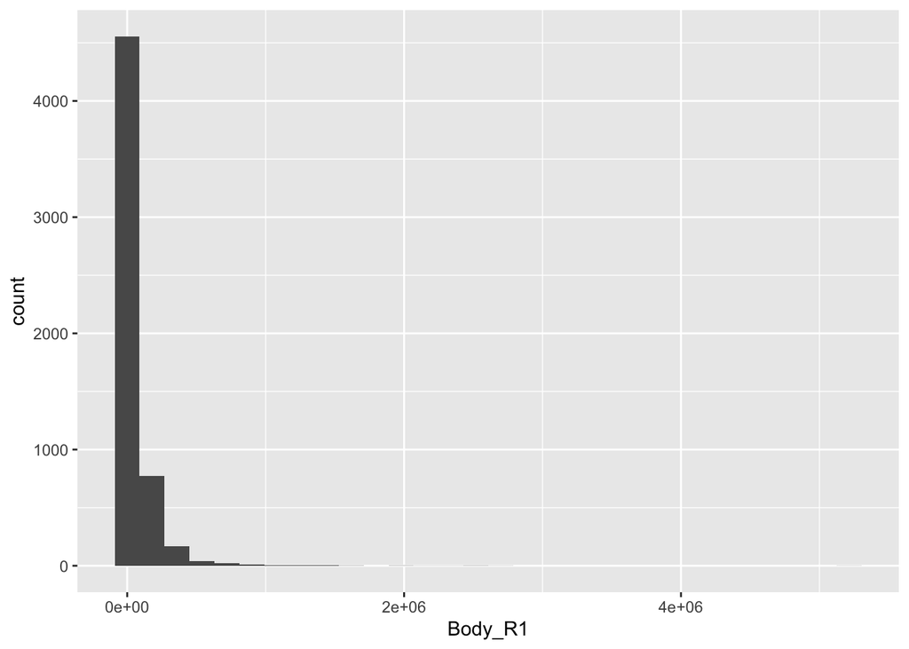

```r
proteinGroups %>%
  ggplot(aes(x=Body_R1))+geom_histogram()
```

Is not normally distributed. We need to log the data to get a normal distribution.

```r
proteinGroups_log<-proteinGroups %>% log2()
```

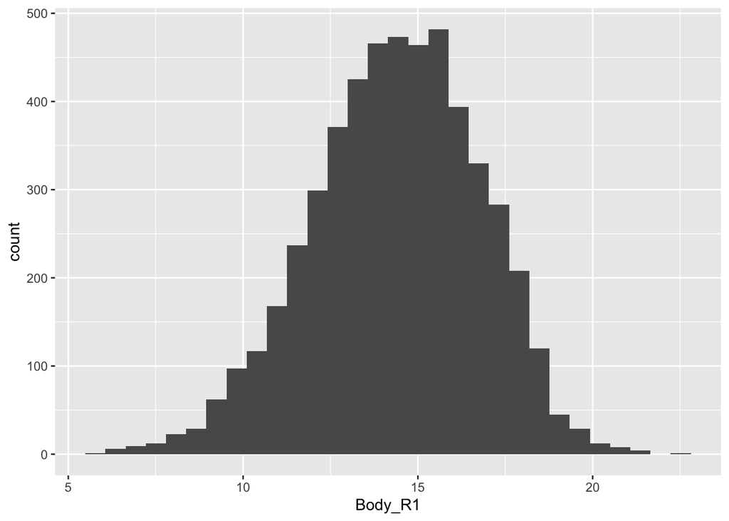

```r
proteinGroups_log %>%
  ggplot(aes(x=Body_R1))+geom_histogram()
```

We need to subtract the median to center distribution to 0. This is standard procedure when we are analyzing proteomics data.

```r
colmed<-apply(proteinGroups_log,2,median)
final_prot<-proteinGroups_log - colmed
```

We can plot all the the columns/samples and check that they are all normally distributed.

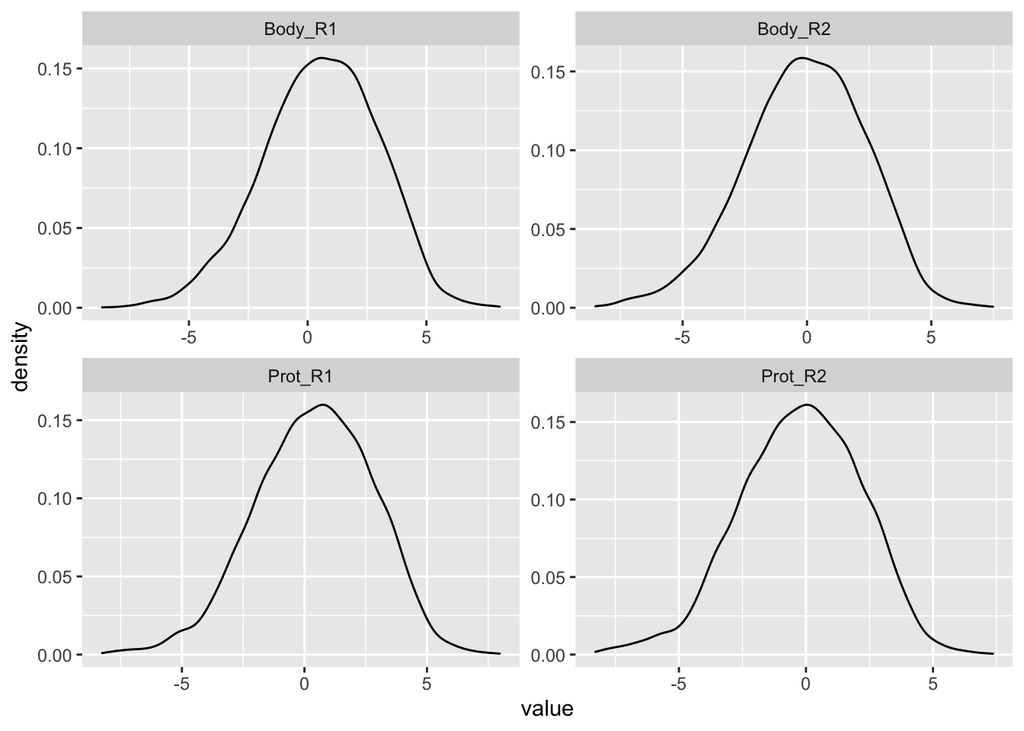

```r
final_prot%>%
  gather() %>%                             # Convert to key-value
  ggplot(aes(value)) +                     # Plot the values
    facet_wrap(~ key, scales = "free") +   # In separate panels
    geom_density()
```

They all seem to follow a normal distribution.

Now we can check correlation

```r
cor.test(proteinGroups_log$Body_R1, proteinGroups_log$Body_R2, method="pearson")
```

```
##
##  Pearson's product-moment correlation
##
## data:  proteinGroups_log$Body_R1 and proteinGroups_log$Body_R2
## t = NaN, df = 5594, p-value = NA
## alternative hypothesis: true correlation is not equal to 0
## 95 percent confidence interval:
##  NaN NaN
## sample estimates:
## cor
## NaN
```

What is the problem? Hint there are -Inf values in the data.

```r
lix <- is.infinite(proteinGroups_log$Body_R1) | is.infinite(proteinGroups_log$Body_R2)
cor.test(proteinGroups_log$Body_R1[!lix], proteinGroups_log$Body_R2[!lix], method="pearson")
```

```
##
##  Pearson's product-moment correlation
##
## data:  proteinGroups_log$Body_R1[!lix] and proteinGroups_log$Body_R2[!lix]
## t = 934.02, df = 5162, p-value < 2.2e-16
## alternative hypothesis: true correlation is not equal to 0
## 95 percent confidence interval:
##  0.9968896 0.9972107
## sample estimates:
##       cor
## 0.9970545
```

This works, but it does output a non-tidy format

```r
as.matrix(cbind(proteinGroups_log$Body_R1[!lix], proteinGroups_log$Body_R2[!lix])) %>%
    rcorr(type = "pearson")  %>%
  tidy()
```

```
## # A tibble: 1 x 5
##   column1 column2 estimate     n p.value
##   <chr>   <chr>      <dbl> <int>   <dbl>
## 1 2       V1         0.997  5164       0
```

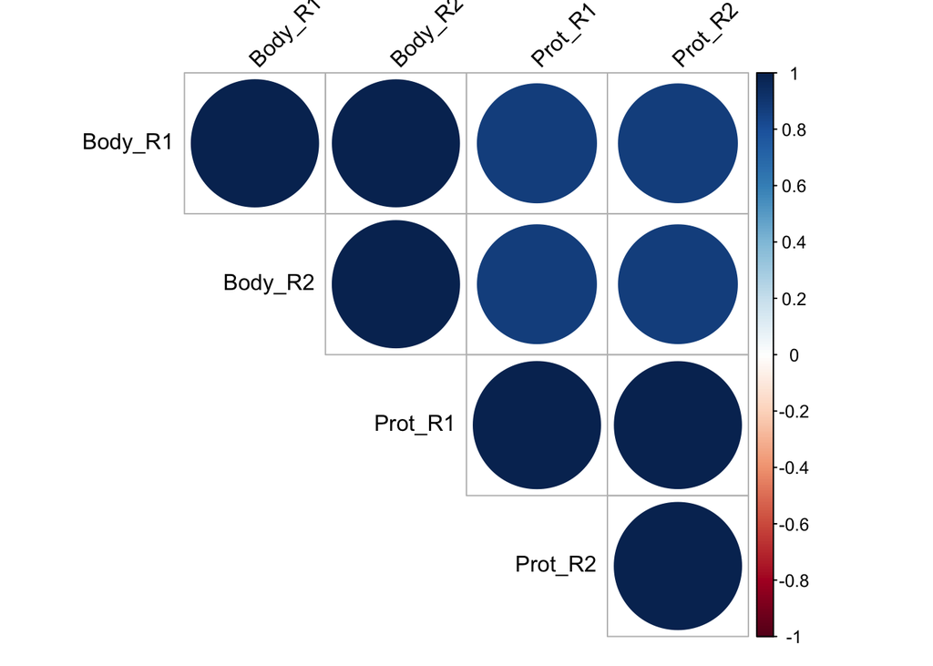

```r
lix <- is.infinite(proteinGroups_log$Body_R1) | is.infinite(proteinGroups_log$Body_R2)| is.infinite(proteinGroups_log$Prot_R1) | is.infinite(proteinGroups_log$Prot_R2)
res <- cor(proteinGroups_log[-which(lix),],method = c("pearson"))
library(corrplot)
corrplot(res, type = "upper", order = "hclust",
         tl.col = "black", tl.srt = 45)
```